# Exercícios – Inferência Estatística

# Exercício 1 – Estimação pontual e propriedades

Considere uma amostra aleatória simples $X_1, \dots, X_n$ de uma população com média $\mu$ e variância $\sigma^2$ (desconhecidas).

Além das questões teóricas, utilize o R para trabalhar com o conjunto de dados abaixo, que representa, por exemplo, o número de horas de sono por noite de $n=12$ estudantes durante um período de exames.

```r
dados_ex1 <- c(6.5, 7.0, 5.8, 8.2, 6.9, 7.5, 5.2, 6.1, 7.8, 6.3, 5.9, 7.1)
dados_ex1
```

```
##  [1] 6.5 7.0 5.8 8.2 6.9 7.5 5.2 6.1 7.8 6.3 5.9 7.1
```

```r
length(dados_ex1)  # tamanho da amostra
```

```
## [1] 12
```

1. **Estimadores usuais**
   1. Indique os estimadores usuais para:
   - a média populacional $\mu$ (denote por $\hat\mu$ ou $\bar X$);
   - a variância populacional $\sigma^2$ (denote por $S^2$).
   2. Escreva as expressões explícitas de $\bar X$ e $S^2$ em função de $X_1,\dots,X_n$.
   3. Usando o R e os dados `dados_ex1`, calcule a média amostral e a variância amostral.

```r
mean(dados_ex1)
```

```
## [1] 6.691667
```

```r
var(dados_ex1)
```

```
## [1] 0.7862879
```

Compare verbalmente os valores obtidos com a definição de $\bar X$ e $S^2$ dada nas alíneas anteriores.

> Isto bate exatamente com as fórmulas da alínea b), `mean` calcula o $\bar X$ e o `var` calcula a variância com denominador $n-1$.
2. **Não-enviesado e consistência**
   1. Explique, em palavras, o que significa dizer que um estimador $\hat\theta$ é **não-enviesado** para um parâmetro $\theta$.

   > Um estimador $\hat\theta$ é **não-enviesado** para o parâmetro $\theta$ se:
   > $$\mathbb{E}[\hat\theta] = \theta$$
   > Em palavras, **em média**, se repetíssemos a experiencia muitas vezes, a média das estimativas coicidiria com o verdadeiro valor do parâmetro; O valor estimado não tende sistematicamnete a sobrestimar nem a subestimar-
   2. Explique, em palavras, o que significa **consistência** de um estimador.

   > Um estimador $\hat\theta_n$ é consistente se, $\hat\theta_n$ quando o tamanho amostral $n$ cresce, se aproxima de $\theta$ com probabilidade cada vez maior. Em suma, com amostras cada vez maiores, a estimativa aproxima-se do valor verdadeiro.
   3. Com base nas suas respostas, comente, de forma qualitativa, por que razão a média amostral $\bar X$ é um estimador “natural” para a média populacional $\mu$.

   > De forma qualitativa: $\bar X$ é a **média** dos valores observados – é o resumo mais simples da tendência central. Em muitas classes de modelos, sabe-se que $\bar X$ é **não-enviesado** para $\mu$ e **consistente**. Além disso, sob condições usuais, é um estimador “eficiente” (tem variância relativamente baixa face a outros estimadores razoáveis). Por isso, é natural usar a média amostral como estimativa da média populacional.
   4. Calcule, em R, o mínimo, máximo, média e desvio padrão dos valores em `dados_ex1`.

```r
min(dados_ex1)
```

```
## [1] 5.2
```

```r
max(dados_ex1)
```

```
## [1] 8.2
```

```r
mean(dados_ex1)
```

```
## [1] 6.691667
```

```r
sd(dados_ex1)
```

```
## [1] 0.8867288
```

# Exercício 2 – Intervalos de confiança para a média

Uma empresa está interessada na duração (em horas) de baterias produzidas numa certa linha de fabrico. Assume-se que a duração das baterias é aproximadamente normal.

Foi recolhida uma amostra de $n = 20$ baterias, com resultados (em horas) guardados num ficheiro `baterias.csv`, numa coluna denominada `duracao`.

1. **Importação e estatísticas descritivas**
   1. Importe os dados para o R e calcule a média amostral $\bar x$ e o desvio-padrão amostral $s$.

```r
dados_baterias <- read.csv("baterias.csv")

mean(dados_baterias$duracao)
```

```
## [1] 101.14
```

```r
sd(dados_baterias$duracao)
```

```
## [1] 7.77766
```

2. **IC para $\mu$ com $\sigma$ desconhecida**
   2. Admitindo que a variância populacional é **desconhecida**, construa um **intervalo de confiança a 95%** para a média duração $\mu$, assumindo normalidade.
   - Indique a estatística utilizada.
   - Refira qual a distribuição (t de Student) envolvida.
   - Apresente a fórmula do intervalo de confiança.
   3. Calcule esse intervalo de confiança explicitamente usando o R (pode usar `t.test`).

```r
t.test(dados_baterias$duracao, conf.level = 0.95)
```

```
##
##  One Sample t-test
##
## data:  dados_baterias$duracao
## t = 58.155, df = 19, p-value < 2.2e-16
## alternative hypothesis: true mean is not equal to 0
## 95 percent confidence interval:
##   97.49994 104.78006
## sample estimates:
## mean of x
##    101.14
```

3. **Interpretação**
   4. Interprete o intervalo de confiança obtido em linguagem simples.

# Exercício 3 – Intervalo de confiança e teste de hipótese para uma proporção

Num inquérito a **200 estudantes**, perguntou-se se utilizam transportes públicos para se deslocar até à escola. Dos 200 estudantes, **90** responderam “Sim”.

1. **Estimador e intervalo de confiança**
   1. Calcule a proporção amostral $\hat p$ de estudantes que utilizam transportes públicos.

   > $$\hat p = \frac{x}{n} = \frac{90}{200} = 0.45$$
   2. Construa, usando uma aproximação normal, um **intervalo de confiança a 95%** para a proporção populacional $p$ de estudantes que usam transportes públicos.
   - Escreva a fórmula geral do IC para $p$.

   > $$\hat p \pm z_{1-\alpha/2}\sqrt{\frac{\hat p(1-\hat p)}{n}}.$$
   - Substitua os valores numéricos e apresente o intervalo.

   > Valores:
   > $$\hat p = 0.45$$
   > $$n = 200$$
   > $$\alpha = 0.05 \to z_{0.975} \approx 1.96$$
   > Erro Padrão:
   > $$\text{EP}(\hat p) = \sqrt{\frac{\hat p(1-\hat p)}{n}} = \sqrt{\frac{0.45
   > \times 0.55}{200}} \approx 0.03518$$
   > Margem de erro:
   > $$1.96 \times 0.03518 \approx 0.06895$$
   > IC:
   > $$0.45 \pm 0.06895 \Rightarrow (0.381, ; 0.519) \ \text{(aprox.)}$$
   > Portanto, um IC a 95% para $p$ é aproximadamente:
   > $$[0.38,; 0.52]$$
   3. Verifique o resultado usando a função `prop.test` no R (sem correcção de continuidade).

```r
sucessos <- 90
n <- 200
prop.test(sucessos, n, correct = FALSE)
```

```
##
##  1-sample proportions test without continuity correction
##
## data:  sucessos out of n, null probability 0.5
## X-squared = 2, df = 1, p-value = 0.1573
## alternative hypothesis: true p is not equal to 0.5
## 95 percent confidence interval:
##  0.3826407 0.5192438
## sample estimates:
##    p
## 0.45
```

2. **Teste de hipótese**
   4. Suponha agora que se quer testar:

   $$H_0: p = 0.4 \quad \text{vs} \quad H_1: p \ne 0.4$$

   a nível de significância $\alpha = 0.05$.
   - Defina a estatística de teste aproximada (baseada na normal) e a sua distribuição sob $H_0$.

   > $$Z = \frac{\hat p - p_0}{\sqrt{\frac{p_0(1-p_0)}{n}}}$$
   - Calcule o valor observado da estatística de teste.

   > Valores:
   > $$\hat p = 0.45$$
   > $$p_0 = 0.4$$
   > $$n = 200$$
   > Substituindo os valores:
   > $$\text{EP}_0 = \sqrt{\frac{0.4 \times 0.6}{200}} =
   > \sqrt{\frac{0.24}{200}} = \sqrt{0.0012} \approx 0.03464.$$
   > $$Z = \frac{0.45 - 0.4}{0.03464} \approx \frac{0.05}{0.03464} \approx 1.44$$
   > Sob $H_0$, $Z \sim N(0,1)$. O p-valor (bilateral) é:
   > $$p\text{-valor} = 2 \times P(Z > 1.44) \approx 2 \times 0.074 \approx
   > 0.148$$
   - Calcule (ou obtenha no R) o $p$-valor.

```r
p_hat <- 90/200
p0 <- 0.4
n <- 200

se0 <- sqrt(p0*(1-p0)/n)
Z <- (p_hat - p0)/se0
Z
```

```
## [1] 1.443376
```

```r
p_valor <- 2 * (1 - pnorm(abs(Z)))
p_valor
```

```
## [1] 0.1489147
```

5. Indique a sua decisão relativamente a $H_0$ e interprete o resultado no contexto do problema (usando linguagem acessível).

> Os dados não fornecem evidência estatisticamente significativa, ao nível de 5%, para concluir que a proporção de estudantes que utilizam transportes públicos é diferente de 40%. A diferença observada (45% vs 40%) pode ser explicada pela variabilidade amostral.

# Exercício 4 – Inferência na regressão linear simples

Pretende-se estudar a relação entre o número de horas de estudo por semana ($X$) e a nota obtida num teste de Estatística ($Y$), numa turma de 30 alunos. Os dados foram guardados num ficheiro `estudo_notas.csv`, com duas colunas: `horas_estudo` e `nota`.

1. **Ajuste do modelo**
   1. Importe os dados para o R e faça um gráfico de dispersão de `nota` versus `horas_estudo`.

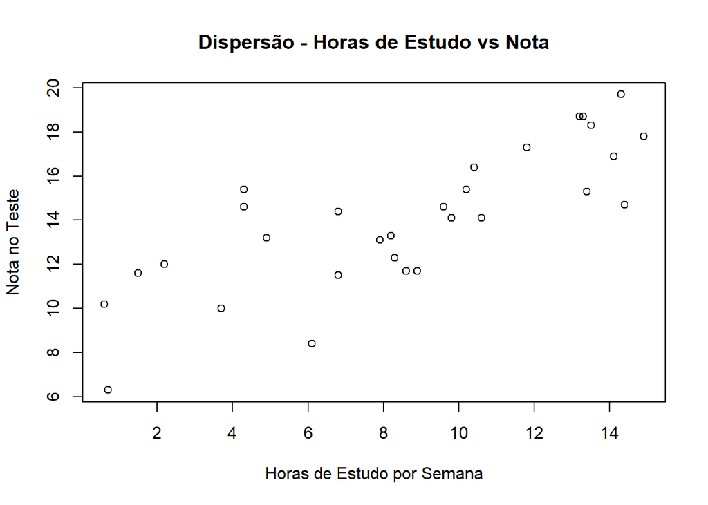

```r
dados_notas <- read.csv("estudo_notas.csv")

plot(dados_notas$horas_estudo, dados_notas$nota,
     xlab = "Horas de Estudo por Semana",
     ylab = "Nota no Teste",
     main = "Dispersão - Horas de Estudo vs Nota"
)
```

2. Ajuste um modelo de **regressão linear simples**:

$$Y = \beta_0 + \beta_1 X + \varepsilon$$

usando a função `lm` do R, e apresente o resumo dos resultados.

```r
mod <- lm(nota ~ horas_estudo, data = dados_notas)
summary(mod)
```

```
##
## Call:
## lm(formula = nota ~ horas_estudo, data = dados_notas)
##
## Residuals:
##     Min      1Q  Median      3Q     Max
## -4.2324 -1.4609  0.0309  1.4065  3.8027
##
## Coefficients:
##              Estimate Std. Error t value Pr(>|t|)
## (Intercept)   9.12448    0.80946  11.272 6.42e-12 ***
## horas_estudo  0.57507    0.08437   6.816 2.10e-07 ***
## ---
## Signif. codes:  0 '***' 0.001 '**' 0.01 '*' 0.05 '.' 0.1 ' ' 1
##
## Residual standard error: 1.987 on 28 degrees of freedom
## Multiple R-squared:  0.624,  Adjusted R-squared:  0.6105
## F-statistic: 46.46 on 1 and 28 DF,  p-value: 2.097e-07
```

2. **Testes de hipótese sobre os coeficientes**
   3. Considere o teste de hipótese:

   $$H_0: \beta_1 = 0 \quad \text{vs} \quad H_1: \beta_1 \ne 0.$$
   - Indique, em termos gerais, o que significa $H_0$ e o que significa $H_1$ neste contexto.

   > **$H_0$**: não há relação linear média entre horas de estudo e nota; aumentando as horas de estudo, a nota esperada não muda (no modelo). **$H_1$**: existe uma relação linear: as notas tendem a aumentar ou diminuir sistematicamente com as horas de estudo.
   - Usando a saída de `summary(mod)`, identifique o valor da estatística t para $\hat\beta_1$ e o respetivo $p$-valor.

   > Na saída de `summary(mod)`, a linha de `horas_estudo` mostra: `Estimate` = $\hat\beta_1$ `Std. Error` = EP($\hat\beta_1$) `t value` = $\hat\beta_1 / \text{EP}(\hat\beta_1)$ `Pr(>|t|)` = p-valor para o teste $H_0: \beta_1 = 0$.
   4. A um nível de significância de 5%, qual é a sua conclusão relativamente a $H_0$? Interprete o resultado em linguagem simples.

   > Se o p-valor para `horas_estudo` for **menor que 0.05**, rejeitamos $H_0$ e concluímos: Há evidência estatística, ao nível de 5%, de que existe uma relação linear entre horas de estudo e nota. Em média, alunos que estudam mais horas tendem a obter notas diferentes (tipicamente mais altas, se $\hat\beta_1 > 0$).

   > Se o p-valor for **maior que 0.05**, não rejeitamos $H_0$ e concluímos: Não há evidência estatisticamente significativa, ao nível de 5%, de que horas de estudo estejam linearmente associadas à nota (no modelo considerado).
3. **Intervalo de confiança para o declive**
   5. Construa um **intervalo de confiança a 95%** para $\beta_1$ usando o R.

```r
confint(mod, level = 0.95)
```

```
##                  2.5 %     97.5 %
## (Intercept)  7.4663881 10.7825788
## horas_estudo 0.4022526  0.7478873
```

6. Interprete o intervalo obtido:
- O que significa dizer que o IC para $\beta_1$ é, por exemplo, `[0.3; 0.8]`?

> Significa que, com base nos dados, valores plausíveis para o efeito médio de uma hora extra de estudo na nota estão entre 0.3 e 0.8 pontos. Ou seja, em média, aumentar uma hora de estudo por semana está associado a um aumneto da nota entre 0.3 e 0.8 valores, aproximadamente.
- Como relaciona essa interpretação com o teste de hipótese realizado anteriormente?

> Como o intervalo **não contém 0**, isso é consistente com o teste de hipótese em que rejeitámos $H_0: \beta_1 = 0$ a 5%. Ou seja, o facto de 0 não pertencer ao IC a 95%, equivale, neste contexto, a dizer que o teste bilateral a 5% rejeita $H_0$.